# What’s in the numbers: A look at the Lusaka Securities Exchange

Aaron Simumba

June 18, 2017

The following excerpt from Bloomberg stands out:

[output not shown]

Investment theory contends that risk taken in an investment must commensurate the return sought. Though equities as a class of investible assets are by their very nature riskier assets relative to other assets like Treasury Bill or Bonds; this in essence frightens most investors to invest in them. More so from the view of the emerging markets, which expose investors to higher levels of volatility relative to more mature and developed markets. In my next post I will look at what was historically being demanded by investors for taking up the extra risk posed by emerging markets.

## In Focus

The following charts give a snapshot of the performance of the Lusaka Securities Exchange All Share index (LASI). For the monthly index data, the period covered is from January 2005 to December 2014. As for the yearly data, it goes all the way back to January 1997- December 2014. Furthermore, I present the data on both time intervals, inclusive and exclusive of the Zambia Consolidated Copper Mines Investment Holdings (ZCCM-IH). This is simply to highlight the effect that the company has on the market index as a whole and on the bigger side, the nation’s economy.

NB: The returns are computed in the local currency (Kwacha).

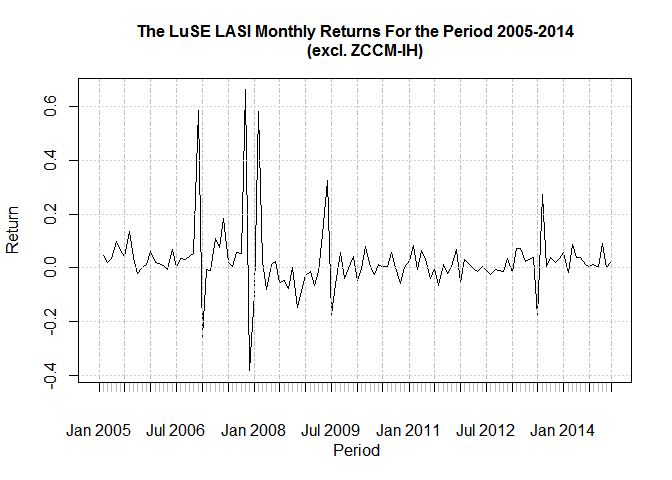

```r
plot(LASI_monthly$Return, xlab=" Period", ylab="Return",main="The LuSE LASI Monthly Returns For the Period 2005-2014
     (excl. ZCCM-IH)",cex.main =1, font.main=2)
```

Most noticeable from the above chart is the greater volatility experienced at the on set of the Global financial crisis. At the height of this crisis we see the index slumping close to -40.0%, conversely, also it hit a record high of more than 60.0% return. The index overall performance is an up-down swing with periods of decent returns and other periods of downward performance.

## Monthly Returns Inclusive of ZCCM-IH

The following chart shows the LASI index inclusive of ZCCM-IH. Since the LASI is a value weighted index, stocks having greater market value tend to have a much more pronounced effect on the movement in the index. For instance, factoring ZCCM-IH’s market capitalization into the LASI index has a telling effect on the overall picture of the index. The chart below shows volatility in certain months relatively lower compared to the chart above which excludes ZCCM-IH. My follow-up posts will closely evaluate this effect and try to elicit some information that explains why this is the case.

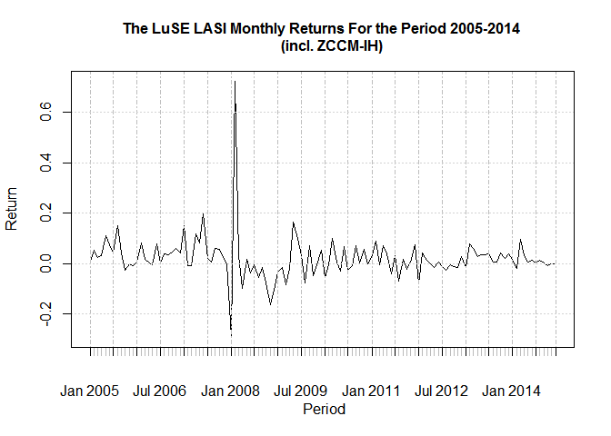

```r
plot(LASI_monthly_zccm$Return,xlab=" Period", ylab="Return", main="The LuSE LASI Monthly Returns For the Period 2005-2014
     (incl. ZCCM-IH)",cex.main =1, font.main=2)
```

The last two charts detail the index on a yearly basis. Though unlike the picture painted from the monthly data, yearly data that goes farther down the years, seem to be carrying a different message on the effect of the company ZCCM-IH. When introduced into the computations, the volatility is more than that observed without its inclusion.

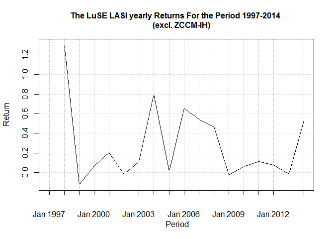

```r
plot(LASI_yearly$Return,xlab=" Period", ylab="Return", main="The LuSE LASI yearly Returns For the Period 1997-2014
     (excl. ZCCM-IH)",cex.main =1, font.main=2)
```

**Inclusive of ZCCM-IH yearly LASI Index returns**

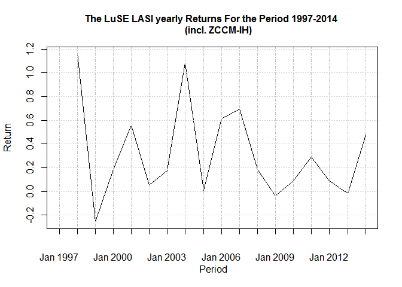

```r
plot(LASI_yearly_zccm$Return, xlab=" Period", ylab="Return", main="The LuSE LASI yearly Returns For the Period 1997-2014
     (incl. ZCCM-IH)",cex.main =1, font.main=2)
```

## Final Remarks

It’s with no doubt the Emerging Markets had a stellar performance the past 2 decades. But what remains inherently attached with these developing markets is: (i.) lack of proper oversight on market monitoring and supervision; (ii.) the lack of or inadequate liquidity in the market among other challenges. In the coming posts I hope to dwell more on the performance of the LuSE and have a look at its peer exchanges in the region.

P.S: I used R statistical Computing Language for my analysis. For the data and the code,you can find them on [my GitHub account](https://github.com/ASimumba/LuSE_Data). Do check them out and run your own analysis.